# Risk Factor Analysis

## Outcome Variable

**Outcome Variable:** y_rate_len

## Predictor Variables

**Intervention Variable:** predfeed36

**Adjustment Set:**

unadjusted

## Stratifying Variables

The analysis was stratified on these variable(s):

- agecat
- studyid
- country

## Data Summary

| agecat | studyid | country | predfeed36 | n_cell | n |
| --- | --- | --- | --- | --- | --- |
| 0-3 months | ki0047075b-MAL-ED | BANGLADESH | 0 | 115 | 242 |
| 0-3 months | ki0047075b-MAL-ED | BANGLADESH | 1 | 127 | 242 |
| 0-3 months | ki0047075b-MAL-ED | BRAZIL | 0 | 151 | 180 |
| 0-3 months | ki0047075b-MAL-ED | BRAZIL | 1 | 29 | 180 |
| 0-3 months | ki0047075b-MAL-ED | INDIA | 0 | 184 | 200 |
| 0-3 months | ki0047075b-MAL-ED | INDIA | 1 | 16 | 200 |
| 0-3 months | ki0047075b-MAL-ED | NEPAL | 0 | 148 | 175 |
| 0-3 months | ki0047075b-MAL-ED | NEPAL | 1 | 27 | 175 |
| 0-3 months | ki0047075b-MAL-ED | PERU | 0 | 149 | 269 |
| 0-3 months | ki0047075b-MAL-ED | PERU | 1 | 120 | 269 |
| 0-3 months | ki0047075b-MAL-ED | SOUTH AFRICA | 0 | 226 | 229 |
| 0-3 months | ki0047075b-MAL-ED | SOUTH AFRICA | 1 | 3 | 229 |
| 0-3 months | ki0047075b-MAL-ED | TANZANIA, UNITED REPUBLIC OF | 0 | 228 | 229 |
| 0-3 months | ki0047075b-MAL-ED | TANZANIA, UNITED REPUBLIC OF | 1 | 1 | 229 |
| 0-3 months | ki1000109-EE | PAKISTAN | 0 | 252 | 594 |
| 0-3 months | ki1000109-EE | PAKISTAN | 1 | 342 | 594 |
| 0-3 months | kiGH5241-JiVitA-3 | BANGLADESH | 0 | 5998 | 30184 |
| 0-3 months | kiGH5241-JiVitA-3 | BANGLADESH | 1 | 24186 | 30184 |
| 0-3 months | kiGH5241-JiVitA-4 | BANGLADESH | 0 | 566 | 3370 |
| 0-3 months | kiGH5241-JiVitA-4 | BANGLADESH | 1 | 2804 | 3370 |
| 3-6 months | ki0047075b-MAL-ED | BANGLADESH | 0 | 107 | 230 |
| 3-6 months | ki0047075b-MAL-ED | BANGLADESH | 1 | 123 | 230 |
| 3-6 months | ki0047075b-MAL-ED | BRAZIL | 0 | 171 | 208 |
| 3-6 months | ki0047075b-MAL-ED | BRAZIL | 1 | 37 | 208 |
| 3-6 months | ki0047075b-MAL-ED | INDIA | 0 | 210 | 229 |
| 3-6 months | ki0047075b-MAL-ED | INDIA | 1 | 19 | 229 |
| 3-6 months | ki0047075b-MAL-ED | NEPAL | 0 | 202 | 233 |
| 3-6 months | ki0047075b-MAL-ED | NEPAL | 1 | 31 | 233 |
| 3-6 months | ki0047075b-MAL-ED | PERU | 0 | 142 | 266 |
| 3-6 months | ki0047075b-MAL-ED | PERU | 1 | 124 | 266 |

[output cut: 60 more lines]

The following strata were considered:

- agecat: 0-3 months, studyid: ki0047075b-MAL-ED, country: BANGLADESH
- agecat: 0-3 months, studyid: ki0047075b-MAL-ED, country: BRAZIL
- agecat: 0-3 months, studyid: ki0047075b-MAL-ED, country: INDIA
- agecat: 0-3 months, studyid: ki0047075b-MAL-ED, country: NEPAL
- agecat: 0-3 months, studyid: ki0047075b-MAL-ED, country: PERU
- agecat: 0-3 months, studyid: ki0047075b-MAL-ED, country: SOUTH AFRICA
- agecat: 0-3 months, studyid: ki0047075b-MAL-ED, country: TANZANIA, UNITED REPUBLIC OF
- agecat: 0-3 months, studyid: ki1000109-EE, country: PAKISTAN
- agecat: 0-3 months, studyid: kiGH5241-JiVitA-3, country: BANGLADESH
- agecat: 0-3 months, studyid: kiGH5241-JiVitA-4, country: BANGLADESH
- agecat: 12-24 months, studyid: ki0047075b-MAL-ED, country: BANGLADESH
- agecat: 12-24 months, studyid: ki0047075b-MAL-ED, country: BRAZIL
- agecat: 12-24 months, studyid: ki0047075b-MAL-ED, country: INDIA
- agecat: 12-24 months, studyid: ki0047075b-MAL-ED, country: NEPAL
- agecat: 12-24 months, studyid: ki0047075b-MAL-ED, country: PERU
- agecat: 12-24 months, studyid: ki0047075b-MAL-ED, country: SOUTH AFRICA
- agecat: 12-24 months, studyid: ki0047075b-MAL-ED, country: TANZANIA, UNITED REPUBLIC OF
- agecat: 12-24 months, studyid: ki1113344-GMS-Nepal, country: NEPAL
- agecat: 12-24 months, studyid: ki1148112-LCNI-5, country: MALAWI
- agecat: 12-24 months, studyid: kiGH5241-JiVitA-3, country: BANGLADESH
- agecat: 12-24 months, studyid: kiGH5241-JiVitA-4, country: BANGLADESH
- agecat: 3-6 months, studyid: ki0047075b-MAL-ED, country: BANGLADESH
- agecat: 3-6 months, studyid: ki0047075b-MAL-ED, country: BRAZIL
- agecat: 3-6 months, studyid: ki0047075b-MAL-ED, country: INDIA
- agecat: 3-6 months, studyid: ki0047075b-MAL-ED, country: NEPAL
- agecat: 3-6 months, studyid: ki0047075b-MAL-ED, country: PERU
- agecat: 3-6 months, studyid: ki0047075b-MAL-ED, country: SOUTH AFRICA
- agecat: 3-6 months, studyid: ki0047075b-MAL-ED, country: TANZANIA, UNITED REPUBLIC OF
- agecat: 3-6 months, studyid: ki1000109-EE, country: PAKISTAN
- agecat: 3-6 months, studyid: ki1113344-GMS-Nepal, country: NEPAL
- agecat: 3-6 months, studyid: kiGH5241-JiVitA-3, country: BANGLADESH
- agecat: 3-6 months, studyid: kiGH5241-JiVitA-4, country: BANGLADESH
- agecat: 6-12 months, studyid: ki0047075b-MAL-ED, country: BANGLADESH
- agecat: 6-12 months, studyid: ki0047075b-MAL-ED, country: BRAZIL
- agecat: 6-12 months, studyid: ki0047075b-MAL-ED, country: INDIA
- agecat: 6-12 months, studyid: ki0047075b-MAL-ED, country: NEPAL
- agecat: 6-12 months, studyid: ki0047075b-MAL-ED, country: PERU
- agecat: 6-12 months, studyid: ki0047075b-MAL-ED, country: SOUTH AFRICA
- agecat: 6-12 months, studyid: ki0047075b-MAL-ED, country: TANZANIA, UNITED REPUBLIC OF
- agecat: 6-12 months, studyid: ki1000109-EE, country: PAKISTAN
- agecat: 6-12 months, studyid: ki1000304b-SAS-FoodSuppl, country: INDIA
- agecat: 6-12 months, studyid: ki1113344-GMS-Nepal, country: NEPAL
- agecat: 6-12 months, studyid: ki1148112-LCNI-5, country: MALAWI
- agecat: 6-12 months, studyid: kiGH5241-JiVitA-3, country: BANGLADESH
- agecat: 6-12 months, studyid: kiGH5241-JiVitA-4, country: BANGLADESH

### Dropped Strata

Some strata were dropped due to rare outcomes:

- agecat: 0-3 months, studyid: ki0047075b-MAL-ED, country: SOUTH AFRICA
- agecat: 0-3 months, studyid: ki0047075b-MAL-ED, country: TANZANIA, UNITED REPUBLIC OF
- agecat: 3-6 months, studyid: ki0047075b-MAL-ED, country: SOUTH AFRICA
- agecat: 3-6 months, studyid: ki0047075b-MAL-ED, country: TANZANIA, UNITED REPUBLIC OF
- agecat: 6-12 months, studyid: ki0047075b-MAL-ED, country: SOUTH AFRICA
- agecat: 6-12 months, studyid: ki0047075b-MAL-ED, country: TANZANIA, UNITED REPUBLIC OF
- agecat: 6-12 months, studyid: ki1000109-EE, country: PAKISTAN
- agecat: 6-12 months, studyid: ki1000304b-SAS-FoodSuppl, country: INDIA
- agecat: 12-24 months, studyid: ki0047075b-MAL-ED, country: SOUTH AFRICA
- agecat: 12-24 months, studyid: ki0047075b-MAL-ED, country: TANZANIA, UNITED REPUBLIC OF

## Methods Detail

We’re interested in the causal parameters $E[Y_a]$ for all values of $a \in \mathcal{A}$. These parameters represent the mean outcome if, possibly contrary to fact, we intervened to set all units to have $A=a$. Under the randomization and positivity assumptions, these are identified by the statistical parameters $\psi_a=E_W[E_{Y|A,W}(Y|A=a,W)]$. In addition, we’re interested in the mean of $Y$, $E[Y]$ under no intervention (the observed mean). We will estimate these parameters by using SuperLearner to fit the relevant likelihood factors – $E_{Y|A,W}(Y|A=a,W)$ and $p(A=a|W)$, and then updating our likelihood fit using a joint TMLE.

For unadjusted analyses ($W=\{\}$), initial likelihoods were estimated using Lrnr_glm to estimate the simple $E(Y|A)$ and Lrnr_mean to estimate $p(A)$. For adjusted analyses, a small library containing Lrnr_glmnet, Lrnr_xgboost, and Lrnr_mean was used.

# Results Detail

## Results Plots

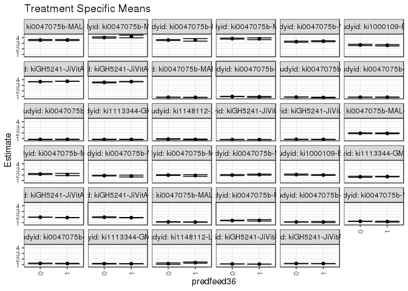

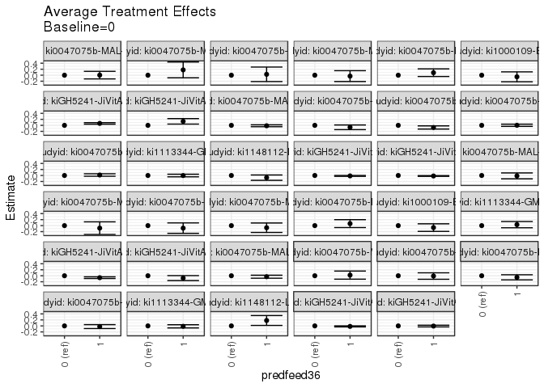

## Results Table

### Parameter: TSM

| agecat | studyid | country | intervention_level | baseline_level | estimate | ci_lower | ci_upper |
| --- | --- | --- | --- | --- | --- | --- | --- |
| 0-3 months | ki0047075b-MAL-ED | BANGLADESH | 0 | NA | 3.5607532 | 3.4686348 | 3.6528717 |
| 0-3 months | ki0047075b-MAL-ED | BANGLADESH | 1 | NA | 3.5637430 | 3.4766051 | 3.6508808 |
| 0-3 months | ki0047075b-MAL-ED | BRAZIL | 0 | NA | 4.0224428 | 3.9108008 | 4.1340848 |
| 0-3 months | ki0047075b-MAL-ED | BRAZIL | 1 | NA | 4.1995167 | 3.9602365 | 4.4387969 |
| 0-3 months | ki0047075b-MAL-ED | INDIA | 0 | NA | 3.5631690 | 3.4828179 | 3.6435201 |
| 0-3 months | ki0047075b-MAL-ED | INDIA | 1 | NA | 3.5925269 | 3.3646673 | 3.8203865 |
| 0-3 months | ki0047075b-MAL-ED | NEPAL | 0 | NA | 3.8251279 | 3.7400462 | 3.9102096 |
| 0-3 months | ki0047075b-MAL-ED | NEPAL | 1 | NA | 3.7950902 | 3.6353713 | 3.9548091 |
| 0-3 months | ki0047075b-MAL-ED | PERU | 0 | NA | 3.2778896 | 3.1903210 | 3.3654582 |
| 0-3 months | ki0047075b-MAL-ED | PERU | 1 | NA | 3.3621671 | 3.2703924 | 3.4539418 |
| 0-3 months | ki1000109-EE | PAKISTAN | 0 | NA | 2.6883206 | 2.5700483 | 2.8065928 |
| 0-3 months | ki1000109-EE | PAKISTAN | 1 | NA | 2.6349021 | 2.5189519 | 2.7508523 |
| 0-3 months | kiGH5241-JiVitA-3 | BANGLADESH | 0 | NA | 3.6413564 | 3.6173162 | 3.6653965 |
| 0-3 months | kiGH5241-JiVitA-3 | BANGLADESH | 1 | NA | 3.7064588 | 3.6940000 | 3.7189177 |
| 0-3 months | kiGH5241-JiVitA-4 | BANGLADESH | 0 | NA | 3.5159550 | 3.4311318 | 3.6007781 |
| 0-3 months | kiGH5241-JiVitA-4 | BANGLADESH | 1 | NA | 3.6496697 | 3.6161984 | 3.6831411 |
| 3-6 months | ki0047075b-MAL-ED | BANGLADESH | 0 | NA | 1.9376358 | 1.8652508 | 2.0100209 |
| 3-6 months | ki0047075b-MAL-ED | BANGLADESH | 1 | NA | 1.9237972 | 1.8564346 | 1.9911597 |
| 3-6 months | ki0047075b-MAL-ED | BRAZIL | 0 | NA | 2.1627820 | 2.0760368 | 2.2495272 |
| 3-6 months | ki0047075b-MAL-ED | BRAZIL | 1 | NA | 2.0786464 | 1.8868122 | 2.2704807 |
| 3-6 months | ki0047075b-MAL-ED | INDIA | 0 | NA | 1.8906820 | 1.8255396 | 1.9558244 |
| 3-6 months | ki0047075b-MAL-ED | INDIA | 1 | NA | 1.8068487 | 1.6458094 | 1.9678880 |
| 3-6 months | ki0047075b-MAL-ED | NEPAL | 0 | NA | 1.9774254 | 1.9168497 | 2.0380010 |
| 3-6 months | ki0047075b-MAL-ED | NEPAL | 1 | NA | 1.9073310 | 1.7616016 | 2.0530603 |
| 3-6 months | ki0047075b-MAL-ED | PERU | 0 | NA | 1.9882617 | 1.8971310 | 2.0793925 |
| 3-6 months | ki0047075b-MAL-ED | PERU | 1 | NA | 2.0554652 | 1.9603982 | 2.1505322 |
| 3-6 months | ki1000109-EE | PAKISTAN | 0 | NA | 2.0636050 | 1.9614125 | 2.1657975 |
| 3-6 months | ki1000109-EE | PAKISTAN | 1 | NA | 1.9979292 | 1.9238473 | 2.0720110 |
| 3-6 months | ki1113344-GMS-Nepal | NEPAL | 0 | NA | 1.6776697 | 1.5827244 | 1.7726151 |
| 3-6 months | ki1113344-GMS-Nepal | NEPAL | 1 | NA | 1.7107896 | 1.6671274 | 1.7544517 |
| 3-6 months | kiGH5241-JiVitA-3 | BANGLADESH | 0 | NA | 1.9625575 | 1.9365850 | 1.9885300 |
| 3-6 months | kiGH5241-JiVitA-3 | BANGLADESH | 1 | NA | 1.8982467 | 1.8855581 | 1.9109353 |
| 3-6 months | kiGH5241-JiVitA-4 | BANGLADESH | 0 | NA | 1.9613680 | 1.8864837 | 2.0362523 |
| 3-6 months | kiGH5241-JiVitA-4 | BANGLADESH | 1 | NA | 1.8839163 | 1.8506700 | 1.9171626 |
| 6-12 months | ki0047075b-MAL-ED | BANGLADESH | 0 | NA | 1.1313931 | 1.0949479 | 1.1678383 |
| 6-12 months | ki0047075b-MAL-ED | BANGLADESH | 1 | NA | 1.0997339 | 1.0658717 | 1.1335961 |
| 6-12 months | ki0047075b-MAL-ED | BRAZIL | 0 | NA | 1.3825781 | 1.3331650 | 1.4319912 |
| 6-12 months | ki0047075b-MAL-ED | BRAZIL | 1 | NA | 1.4040796 | 1.2784560 | 1.5297031 |
| 6-12 months | ki0047075b-MAL-ED | INDIA | 0 | NA | 1.1217969 | 1.0922521 | 1.1513416 |
| 6-12 months | ki0047075b-MAL-ED | INDIA | 1 | NA | 1.1125742 | 1.0089097 | 1.2162388 |
| 6-12 months | ki0047075b-MAL-ED | NEPAL | 0 | NA | 1.2290258 | 1.2020554 | 1.2559963 |
| 6-12 months | ki0047075b-MAL-ED | NEPAL | 1 | NA | 1.1768365 | 1.0955921 | 1.2580808 |
| 6-12 months | ki0047075b-MAL-ED | PERU | 0 | NA | 1.2211484 | 1.1731468 | 1.2691500 |
| 6-12 months | ki0047075b-MAL-ED | PERU | 1 | NA | 1.1982519 | 1.1543860 | 1.2421179 |
| 6-12 months | ki1113344-GMS-Nepal | NEPAL | 0 | NA | 1.1765878 | 1.1281587 | 1.2250168 |
| 6-12 months | ki1113344-GMS-Nepal | NEPAL | 1 | NA | 1.1624954 | 1.1409896 | 1.1840013 |
| 6-12 months | ki1148112-LCNI-5 | MALAWI | 0 | NA | 1.1850352 | 1.0606518 | 1.3094187 |
| 6-12 months | ki1148112-LCNI-5 | MALAWI | 1 | NA | 1.3658051 | 1.2577692 | 1.4738411 |
| 6-12 months | kiGH5241-JiVitA-3 | BANGLADESH | 0 | NA | 1.1270421 | 1.1104496 | 1.1436346 |
| 6-12 months | kiGH5241-JiVitA-3 | BANGLADESH | 1 | NA | 1.1103937 | 1.1025588 | 1.1182286 |
| 6-12 months | kiGH5241-JiVitA-4 | BANGLADESH | 0 | NA | 1.2066878 | 1.1813941 | 1.2319816 |
| 6-12 months | kiGH5241-JiVitA-4 | BANGLADESH | 1 | NA | 1.2009094 | 1.1881455 | 1.2136733 |
| 12-24 months | ki0047075b-MAL-ED | BANGLADESH | 0 | NA | 0.8544529 | 0.8302599 | 0.8786458 |
| 12-24 months | ki0047075b-MAL-ED | BANGLADESH | 1 | NA | 0.8403500 | 0.8190425 | 0.8616574 |
| 12-24 months | ki0047075b-MAL-ED | BRAZIL | 0 | NA | 0.9935070 | 0.9596325 | 1.0273815 |
| 12-24 months | ki0047075b-MAL-ED | BRAZIL | 1 | NA | 0.9281531 | 0.8580604 | 0.9982458 |
| 12-24 months | ki0047075b-MAL-ED | INDIA | 0 | NA | 0.8860667 | 0.8679522 | 0.9041812 |
| 12-24 months | ki0047075b-MAL-ED | INDIA | 1 | NA | 0.8148959 | 0.7651213 | 0.8646704 |
| 12-24 months | ki0047075b-MAL-ED | NEPAL | 0 | NA | 0.8613854 | 0.8444407 | 0.8783300 |
| 12-24 months | ki0047075b-MAL-ED | NEPAL | 1 | NA | 0.8639020 | 0.8311486 | 0.8966554 |
| 12-24 months | ki0047075b-MAL-ED | PERU | 0 | NA | 0.8390005 | 0.8079944 | 0.8700067 |
| 12-24 months | ki0047075b-MAL-ED | PERU | 1 | NA | 0.8549420 | 0.8285699 | 0.8813140 |
| 12-24 months | ki1113344-GMS-Nepal | NEPAL | 0 | NA | 0.8368090 | 0.7967643 | 0.8768537 |
| 12-24 months | ki1113344-GMS-Nepal | NEPAL | 1 | NA | 0.8349302 | 0.8175550 | 0.8523055 |
| 12-24 months | ki1148112-LCNI-5 | MALAWI | 0 | NA | 0.9052456 | 0.8493606 | 0.9611306 |
| 12-24 months | ki1148112-LCNI-5 | MALAWI | 1 | NA | 0.8330056 | 0.7639315 | 0.9020797 |
| 12-24 months | kiGH5241-JiVitA-3 | BANGLADESH | 0 | NA | 0.8070518 | 0.7935400 | 0.8205636 |
| 12-24 months | kiGH5241-JiVitA-3 | BANGLADESH | 1 | NA | 0.7933965 | 0.7870206 | 0.7997724 |
| 12-24 months | kiGH5241-JiVitA-4 | BANGLADESH | 0 | NA | 0.8619198 | 0.8501208 | 0.8737187 |
| 12-24 months | kiGH5241-JiVitA-4 | BANGLADESH | 1 | NA | 0.8454382 | 0.8389257 | 0.8519507 |

### Parameter: E(Y)

| agecat | studyid | country | intervention_level | baseline_level | estimate | ci_lower | ci_upper |
| --- | --- | --- | --- | --- | --- | --- | --- |
| 0-3 months | ki0047075b-MAL-ED | BANGLADESH | NA | NA | 3.5623222 | 3.4990175 | 3.6256270 |
| 0-3 months | ki0047075b-MAL-ED | BRAZIL | NA | NA | 4.0509714 | 3.9492443 | 4.1526985 |
| 0-3 months | ki0047075b-MAL-ED | INDIA | NA | NA | 3.5655176 | 3.4893722 | 3.6416631 |
| 0-3 months | ki0047075b-MAL-ED | NEPAL | NA | NA | 3.8204935 | 3.7444190 | 3.8965681 |
| 0-3 months | ki0047075b-MAL-ED | PERU | NA | NA | 3.3154855 | 3.2518148 | 3.3791562 |
| 0-3 months | ki1000109-EE | PAKISTAN | NA | NA | 2.6575645 | 2.5739973 | 2.7411317 |
| 0-3 months | kiGH5241-JiVitA-3 | BANGLADESH | NA | NA | 3.6935220 | 3.6819690 | 3.7050750 |
| 0-3 months | kiGH5241-JiVitA-4 | BANGLADESH | NA | NA | 3.6272120 | 3.5957777 | 3.6586463 |
| 3-6 months | ki0047075b-MAL-ED | BANGLADESH | NA | NA | 1.9302352 | 1.8809143 | 1.9795560 |
| 3-6 months | ki0047075b-MAL-ED | BRAZIL | NA | NA | 2.1478156 | 2.0686357 | 2.2269955 |
| 3-6 months | ki0047075b-MAL-ED | INDIA | NA | NA | 1.8837264 | 1.8224393 | 1.9450135 |
| 3-6 months | ki0047075b-MAL-ED | NEPAL | NA | NA | 1.9680995 | 1.9120346 | 2.0241643 |
| 3-6 months | ki0047075b-MAL-ED | PERU | NA | NA | 2.0195897 | 1.9536580 | 2.0855214 |
| 3-6 months | ki1000109-EE | PAKISTAN | NA | NA | 2.0241201 | 1.9636505 | 2.0845898 |
| 3-6 months | ki1113344-GMS-Nepal | NEPAL | NA | NA | 1.7041512 | 1.6643719 | 1.7439304 |
| 3-6 months | kiGH5241-JiVitA-3 | BANGLADESH | NA | NA | 1.9109679 | 1.8993348 | 1.9226010 |
| 3-6 months | kiGH5241-JiVitA-4 | BANGLADESH | NA | NA | 1.8963017 | 1.8659335 | 1.9266699 |
| 6-12 months | ki0047075b-MAL-ED | BANGLADESH | NA | NA | 1.1143347 | 1.0894390 | 1.1392304 |
| 6-12 months | ki0047075b-MAL-ED | BRAZIL | NA | NA | 1.3863464 | 1.3400121 | 1.4326807 |
| 6-12 months | ki0047075b-MAL-ED | INDIA | NA | NA | 1.1210558 | 1.0926349 | 1.1494766 |
| 6-12 months | ki0047075b-MAL-ED | NEPAL | NA | NA | 1.2224454 | 1.1966480 | 1.2482429 |
| 6-12 months | ki0047075b-MAL-ED | PERU | NA | NA | 1.2102315 | 1.1775158 | 1.2429472 |
| 6-12 months | ki1113344-GMS-Nepal | NEPAL | NA | NA | 1.1652836 | 1.1455437 | 1.1850235 |
| 6-12 months | ki1148112-LCNI-5 | MALAWI | NA | NA | 1.2437855 | 1.1489803 | 1.3385906 |
| 6-12 months | kiGH5241-JiVitA-3 | BANGLADESH | NA | NA | 1.1137217 | 1.1063529 | 1.1210904 |
| 6-12 months | kiGH5241-JiVitA-4 | BANGLADESH | NA | NA | 1.2021162 | 1.1906438 | 1.2135885 |
| 12-24 months | ki0047075b-MAL-ED | BANGLADESH | NA | NA | 0.8466791 | 0.8306555 | 0.8627027 |
| 12-24 months | ki0047075b-MAL-ED | BRAZIL | NA | NA | 0.9816245 | 0.9508764 | 1.0123725 |
| 12-24 months | ki0047075b-MAL-ED | INDIA | NA | NA | 0.8803730 | 0.8630530 | 0.8976931 |
| 12-24 months | ki0047075b-MAL-ED | NEPAL | NA | NA | 0.8617083 | 0.8463512 | 0.8770654 |
| 12-24 months | ki0047075b-MAL-ED | PERU | NA | NA | 0.8463453 | 0.8256453 | 0.8670453 |
| 12-24 months | ki1113344-GMS-Nepal | NEPAL | NA | NA | 0.8352708 | 0.8193000 | 0.8512417 |
| 12-24 months | ki1148112-LCNI-5 | MALAWI | NA | NA | 0.8835736 | 0.8376943 | 0.9294529 |
| 12-24 months | kiGH5241-JiVitA-3 | BANGLADESH | NA | NA | 0.7961751 | 0.7903156 | 0.8020346 |
| 12-24 months | kiGH5241-JiVitA-4 | BANGLADESH | NA | NA | 0.8490566 | 0.8431830 | 0.8549302 |

### Parameter: ATE

| agecat | studyid | country | intervention_level | baseline_level | estimate | ci_lower | ci_upper |
| --- | --- | --- | --- | --- | --- | --- | --- |
| 0-3 months | ki0047075b-MAL-ED | BANGLADESH | 0 | 0 | 0.0000000 | 0.0000000 | 0.0000000 |
| 0-3 months | ki0047075b-MAL-ED | BANGLADESH | 1 | 0 | 0.0029898 | -0.1238125 | 0.1297920 |
| 0-3 months | ki0047075b-MAL-ED | BRAZIL | 0 | 0 | 0.0000000 | 0.0000000 | 0.0000000 |
| 0-3 months | ki0047075b-MAL-ED | BRAZIL | 1 | 0 | 0.1770739 | -0.0869696 | 0.4411174 |
| 0-3 months | ki0047075b-MAL-ED | INDIA | 0 | 0 | 0.0000000 | 0.0000000 | 0.0000000 |
| 0-3 months | ki0047075b-MAL-ED | INDIA | 1 | 0 | 0.0293579 | -0.2122540 | 0.2709698 |
| 0-3 months | ki0047075b-MAL-ED | NEPAL | 0 | 0 | 0.0000000 | 0.0000000 | 0.0000000 |
| 0-3 months | ki0047075b-MAL-ED | NEPAL | 1 | 0 | -0.0300377 | -0.2110046 | 0.1509292 |
| 0-3 months | ki0047075b-MAL-ED | PERU | 0 | 0 | 0.0000000 | 0.0000000 | 0.0000000 |
| 0-3 months | ki0047075b-MAL-ED | PERU | 1 | 0 | 0.0842775 | -0.0425722 | 0.2111272 |
| 0-3 months | ki1000109-EE | PAKISTAN | 0 | 0 | 0.0000000 | 0.0000000 | 0.0000000 |
| 0-3 months | ki1000109-EE | PAKISTAN | 1 | 0 | -0.0534185 | -0.2190469 | 0.1122099 |
| 0-3 months | kiGH5241-JiVitA-3 | BANGLADESH | 0 | 0 | 0.0000000 | 0.0000000 | 0.0000000 |
| 0-3 months | kiGH5241-JiVitA-3 | BANGLADESH | 1 | 0 | 0.0651025 | 0.0392957 | 0.0909093 |
| 0-3 months | kiGH5241-JiVitA-4 | BANGLADESH | 0 | 0 | 0.0000000 | 0.0000000 | 0.0000000 |
| 0-3 months | kiGH5241-JiVitA-4 | BANGLADESH | 1 | 0 | 0.1337148 | 0.0425823 | 0.2248472 |
| 3-6 months | ki0047075b-MAL-ED | BANGLADESH | 0 | 0 | 0.0000000 | 0.0000000 | 0.0000000 |
| 3-6 months | ki0047075b-MAL-ED | BANGLADESH | 1 | 0 | -0.0138386 | -0.1127189 | 0.0850417 |
| 3-6 months | ki0047075b-MAL-ED | BRAZIL | 0 | 0 | 0.0000000 | 0.0000000 | 0.0000000 |
| 3-6 months | ki0047075b-MAL-ED | BRAZIL | 1 | 0 | -0.0841356 | -0.2946709 | 0.1263998 |
| 3-6 months | ki0047075b-MAL-ED | INDIA | 0 | 0 | 0.0000000 | 0.0000000 | 0.0000000 |
| 3-6 months | ki0047075b-MAL-ED | INDIA | 1 | 0 | -0.0838333 | -0.2575492 | 0.0898826 |
| 3-6 months | ki0047075b-MAL-ED | NEPAL | 0 | 0 | 0.0000000 | 0.0000000 | 0.0000000 |
| 3-6 months | ki0047075b-MAL-ED | NEPAL | 1 | 0 | -0.0700944 | -0.2279122 | 0.0877234 |
| 3-6 months | ki0047075b-MAL-ED | PERU | 0 | 0 | 0.0000000 | 0.0000000 | 0.0000000 |
| 3-6 months | ki0047075b-MAL-ED | PERU | 1 | 0 | 0.0672035 | -0.0644876 | 0.1988946 |
| 3-6 months | ki1000109-EE | PAKISTAN | 0 | 0 | 0.0000000 | 0.0000000 | 0.0000000 |
| 3-6 months | ki1000109-EE | PAKISTAN | 1 | 0 | -0.0656759 | -0.1918956 | 0.0605439 |
| 3-6 months | ki1113344-GMS-Nepal | NEPAL | 0 | 0 | 0.0000000 | 0.0000000 | 0.0000000 |
| 3-6 months | ki1113344-GMS-Nepal | NEPAL | 1 | 0 | 0.0331198 | -0.0713838 | 0.1376234 |
| 3-6 months | kiGH5241-JiVitA-3 | BANGLADESH | 0 | 0 | 0.0000000 | 0.0000000 | 0.0000000 |
| 3-6 months | kiGH5241-JiVitA-3 | BANGLADESH | 1 | 0 | -0.0643108 | -0.0926710 | -0.0359506 |
| 3-6 months | kiGH5241-JiVitA-4 | BANGLADESH | 0 | 0 | 0.0000000 | 0.0000000 | 0.0000000 |
| 3-6 months | kiGH5241-JiVitA-4 | BANGLADESH | 1 | 0 | -0.0774517 | -0.1595491 | 0.0046456 |
| 6-12 months | ki0047075b-MAL-ED | BANGLADESH | 0 | 0 | 0.0000000 | 0.0000000 | 0.0000000 |
| 6-12 months | ki0047075b-MAL-ED | BANGLADESH | 1 | 0 | -0.0316592 | -0.0814076 | 0.0180892 |
| 6-12 months | ki0047075b-MAL-ED | BRAZIL | 0 | 0 | 0.0000000 | 0.0000000 | 0.0000000 |
| 6-12 months | ki0047075b-MAL-ED | BRAZIL | 1 | 0 | 0.0215014 | -0.1134909 | 0.1564937 |
| 6-12 months | ki0047075b-MAL-ED | INDIA | 0 | 0 | 0.0000000 | 0.0000000 | 0.0000000 |
| 6-12 months | ki0047075b-MAL-ED | INDIA | 1 | 0 | -0.0092226 | -0.1170152 | 0.0985699 |
| 6-12 months | ki0047075b-MAL-ED | NEPAL | 0 | 0 | 0.0000000 | 0.0000000 | 0.0000000 |
| 6-12 months | ki0047075b-MAL-ED | NEPAL | 1 | 0 | -0.0521894 | -0.1377934 | 0.0334146 |
| 6-12 months | ki0047075b-MAL-ED | PERU | 0 | 0 | 0.0000000 | 0.0000000 | 0.0000000 |
| 6-12 months | ki0047075b-MAL-ED | PERU | 1 | 0 | -0.0228965 | -0.0879224 | 0.0421295 |
| 6-12 months | ki1113344-GMS-Nepal | NEPAL | 0 | 0 | 0.0000000 | 0.0000000 | 0.0000000 |
| 6-12 months | ki1113344-GMS-Nepal | NEPAL | 1 | 0 | -0.0140923 | -0.0670817 | 0.0388970 |
| 6-12 months | ki1148112-LCNI-5 | MALAWI | 0 | 0 | 0.0000000 | 0.0000000 | 0.0000000 |
| 6-12 months | ki1148112-LCNI-5 | MALAWI | 1 | 0 | 0.1807699 | 0.0160186 | 0.3455212 |
| 6-12 months | kiGH5241-JiVitA-3 | BANGLADESH | 0 | 0 | 0.0000000 | 0.0000000 | 0.0000000 |
| 6-12 months | kiGH5241-JiVitA-3 | BANGLADESH | 1 | 0 | -0.0166484 | -0.0343391 | 0.0010423 |
| 6-12 months | kiGH5241-JiVitA-4 | BANGLADESH | 0 | 0 | 0.0000000 | 0.0000000 | 0.0000000 |
| 6-12 months | kiGH5241-JiVitA-4 | BANGLADESH | 1 | 0 | -0.0057784 | -0.0339331 | 0.0223763 |
| 12-24 months | ki0047075b-MAL-ED | BANGLADESH | 0 | 0 | 0.0000000 | 0.0000000 | 0.0000000 |
| 12-24 months | ki0047075b-MAL-ED | BANGLADESH | 1 | 0 | -0.0141029 | -0.0463412 | 0.0181354 |
| 12-24 months | ki0047075b-MAL-ED | BRAZIL | 0 | 0 | 0.0000000 | 0.0000000 | 0.0000000 |
| 12-24 months | ki0047075b-MAL-ED | BRAZIL | 1 | 0 | -0.0653539 | -0.1432029 | 0.0124951 |
| 12-24 months | ki0047075b-MAL-ED | INDIA | 0 | 0 | 0.0000000 | 0.0000000 | 0.0000000 |
| 12-24 months | ki0047075b-MAL-ED | INDIA | 1 | 0 | -0.0711709 | -0.1241392 | -0.0182025 |
| 12-24 months | ki0047075b-MAL-ED | NEPAL | 0 | 0 | 0.0000000 | 0.0000000 | 0.0000000 |
| 12-24 months | ki0047075b-MAL-ED | NEPAL | 1 | 0 | 0.0025166 | -0.0343602 | 0.0393935 |
| 12-24 months | ki0047075b-MAL-ED | PERU | 0 | 0 | 0.0000000 | 0.0000000 | 0.0000000 |
| 12-24 months | ki0047075b-MAL-ED | PERU | 1 | 0 | 0.0159414 | -0.0247632 | 0.0566460 |
| 12-24 months | ki1113344-GMS-Nepal | NEPAL | 0 | 0 | 0.0000000 | 0.0000000 | 0.0000000 |
| 12-24 months | ki1113344-GMS-Nepal | NEPAL | 1 | 0 | -0.0018788 | -0.0455305 | 0.0417730 |
| 12-24 months | ki1148112-LCNI-5 | MALAWI | 0 | 0 | 0.0000000 | 0.0000000 | 0.0000000 |
| 12-24 months | ki1148112-LCNI-5 | MALAWI | 1 | 0 | -0.0722400 | -0.1610902 | 0.0166103 |
| 12-24 months | kiGH5241-JiVitA-3 | BANGLADESH | 0 | 0 | 0.0000000 | 0.0000000 | 0.0000000 |
| 12-24 months | kiGH5241-JiVitA-3 | BANGLADESH | 1 | 0 | -0.0136553 | -0.0283952 | 0.0010845 |
| 12-24 months | kiGH5241-JiVitA-4 | BANGLADESH | 0 | 0 | 0.0000000 | 0.0000000 | 0.0000000 |
| 12-24 months | kiGH5241-JiVitA-4 | BANGLADESH | 1 | 0 | -0.0164816 | -0.0295199 | -0.0034434 |